# Practical Machine Learning Project-write up

Geeta Nain

September 25, 2015

## Introduction

- We have training and testing datasets from accelerometers on the belt, forearm, arm, and dumbell of six participants, who participated in dumbell lifting exercise in five different way.The five ways, as described in the study, were Class A (exactly according to the specification), Class B (throwing the elbows to the front) , Class C (lifting the dumbbell only halfway) , class D (lowering the dumbbell only halfway) and Class E (throwing the hips to the front). -Training data consists of accelerometer data (having all these classes) and a label(classe) identifying the quality of the activity the participant was doing. Our testing data consists of accelerometer data (all classes) without the identifying label. so, This report consist mainly following points to predict the manner (lebel) for 20 testing observation.

1.Data preprocessing 2.Building Model using different methods (i.e. rpart, rf etc.) 3.Applying cross validation 4.Estimated out of sample error 4.Predictions

## Data Preprocessing

1.Loading packages and importing data

```r
library(AppliedPredictiveModeling)
library(caret)
library(rattle)
```

```r
library(rpart.plot)
library(randomForest)
training <- "pml-training.csv"
testing <- "pml-testing.csv"

# Importing data considering null values as NA
training <- read.csv(training, na.strings=c("NA",""), header=TRUE)
column_training <- colnames(training)

testing <- read.csv(testing, na.strings=c("NA",""), header=TRUE)
column_testing <- colnames(testing)

# Verify that the column names (excluding classe and problem_id) are identical in the training and test set.
all.equal(column_training[1:length(column_training)-1], column_testing[1:length(column_training)-1])
```

```
## [1] TRUE
```

2. Partioning the data

```r
Train <- createDataPartition(y=training$classe, p=0.6, list=FALSE)
trainpart <- training[Train, ];
testpart <- training[-Train, ]
dim(trainpart)
```

```
## [1] 11776   160
```

```r
dim(testpart)
```

```
## [1] 7846  160
```

3. Removing columns having Nas values , zero variance and which do not make sense for predictions.

```r
# remove variables that are almost always NA
NAs <- sapply(trainpart, function(x) mean(is.na(x))) > 0.95
trainpart <- trainpart[, NAs==F]
testpart <- testpart[, NAs==F]

# remove variables with nearly zero variance
nzv <- nearZeroVar(trainpart)
trainpart <- trainpart[, -nzv]
testpart <- testpart[, -nzv]

# remove variables that don't make sense for prediction (X, user_name, raw_timestamp_part_1, raw_timestamp_part_2, cvtd_timestamp, new_windo, num_window), which are the first seven variables
trainpart <- trainpart[, -(1:7)]
testpart <- testpart[, -(1:7)]
```

## Building model using different method

### Model1 using method rpart

1. With no extra features.

```r
set.seed(666)
modFit <- train(trainpart$classe ~ ., data =trainpart, method="rpart")

print(modFit, digits=3)
```

```
## CART
##
## 11776 samples
##    51 predictor
##     5 classes: 'A', 'B', 'C', 'D', 'E'
##
## No pre-processing
## Resampling: Bootstrapped (25 reps)
##
## Summary of sample sizes: 11776, 11776, 11776, 11776, 11776, 11776, ...
##
## Resampling results across tuning parameters:
##
##   cp      Accuracy  Kappa  Accuracy SD  Kappa SD
##   0.0299  0.526     0.392  0.0399       0.0604
##   0.0323  0.515     0.377  0.0398       0.0609
##   0.0638  0.349     0.106  0.0860       0.1447
##
## Accuracy was used to select the optimal model using  the largest value.
## The final value used for the model was cp = 0.0299.
```

```r
print(modFit$finalModel, digits=3)
```

```
## n= 11776
##
## node), split, n, loss, yval, (yprob)
##       * denotes terminal node
##
##  1) root 11776 8430 A (0.28 0.19 0.17 0.16 0.18)
##    2) pitch_forearm< -33.7 947   11 A (0.99 0.012 0 0 0) *
##    3) pitch_forearm>=-33.7 10829 8420 A (0.22 0.21 0.19 0.18 0.2)
##      6) accel_belt_z>=-186 10165 7770 A (0.24 0.22 0.2 0.19 0.15)
##       12) magnet_dumbbell_y< 440 8516 6170 A (0.28 0.18 0.23 0.19 0.13)
##         24) roll_forearm< 124 5370 3260 A (0.39 0.18 0.17 0.16 0.092) *
##         25) roll_forearm>=124 3146 2100 C (0.074 0.17 0.33 0.23 0.19)
##           50) accel_forearm_x>=-104 2216 1390 C (0.084 0.21 0.37 0.1 0.23) *
##           51) accel_forearm_x< -104 930  444 D (0.052 0.091 0.23 0.52 0.1) *
##       13) magnet_dumbbell_y>=440 1649  886 B (0.031 0.46 0.045 0.21 0.25) *
##      7) accel_belt_z< -186 664   16 E (0.024 0 0 0 0.98) *
```

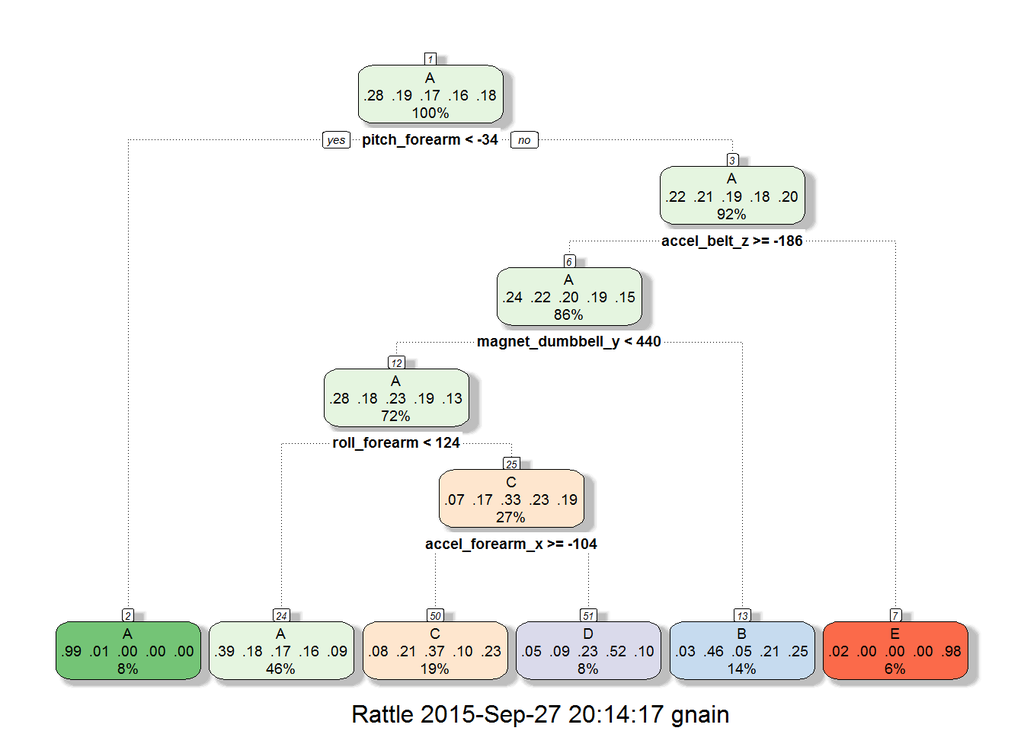

```r
fancyRpartPlot(modFit$finalModel)
```

```r
predictions <- predict(modFit, newdata=testpart)
print(confusionMatrix(predictions, testpart$classe), digits=4)
```

```
## Confusion Matrix and Statistics
##
##           Reference
## Prediction    A    B    C    D    E
##          A 2016  614  649  580  345
##          B   30  523   33  225  289
##          C  129  327  542  155  325
##          D   40   53  144  326   73
##          E   17    1    0    0  410
##
## Overall Statistics
##
##                Accuracy : 0.4865
##                  95% CI : (0.4754, 0.4976)
##     No Information Rate : 0.2845
##     P-Value [Acc > NIR] : < 2.2e-16
##
##                   Kappa : 0.3281
##  Mcnemar's Test P-Value : < 2.2e-16
##
## Statistics by Class:
##
##                      Class: A Class: B Class: C Class: D Class: E
## Sensitivity            0.9032  0.34453  0.39620  0.25350  0.28433
## Specificity            0.6103  0.90882  0.85551  0.95274  0.99719
## Pos Pred Value         0.4795  0.47545  0.36671  0.51258  0.95794
## Neg Pred Value         0.9407  0.85251  0.87029  0.86685  0.86088
## Prevalence             0.2845  0.19347  0.17436  0.16391  0.18379
## Detection Rate         0.2569  0.06666  0.06908  0.04155  0.05226
## Detection Prevalence   0.5358  0.14020  0.18838  0.08106  0.05455
## Balanced Accuracy      0.7567  0.62668  0.62585  0.60312  0.64076
```

```r
set.seed(666)
modFit <- train(trainpart$classe ~ .,  preProcess=c("center", "scale"), data = trainpart, method="rpart")
print(modFit, digits=3)
```

```
## CART
##
## 11776 samples
##    51 predictor
##     5 classes: 'A', 'B', 'C', 'D', 'E'
##
## Pre-processing: centered, scaled
## Resampling: Bootstrapped (25 reps)
##
## Summary of sample sizes: 11776, 11776, 11776, 11776, 11776, 11776, ...
##
## Resampling results across tuning parameters:
##
##   cp      Accuracy  Kappa  Accuracy SD  Kappa SD
##   0.0299  0.526     0.392  0.0399       0.0604
##   0.0323  0.515     0.377  0.0398       0.0609
##   0.0638  0.349     0.106  0.0860       0.1447
##
## Accuracy was used to select the optimal model using  the largest value.
## The final value used for the model was cp = 0.0299.
```

3. With only cross validation.

```r
set.seed(666)
modFit <- train(trainpart$classe ~ .,  trControl=trainControl(method = "cv", number = 4), data = trainpart, method="rpart")
print(modFit, digits=3)
```

```
## CART
##
## 11776 samples
##    51 predictor
##     5 classes: 'A', 'B', 'C', 'D', 'E'
##
## No pre-processing
## Resampling: Cross-Validated (4 fold)
##
## Summary of sample sizes: 8831, 8833, 8831, 8833
##
## Resampling results across tuning parameters:
##
##   cp      Accuracy  Kappa  Accuracy SD  Kappa SD
##   0.0299  0.519     0.377  0.0324       0.0518
##   0.0323  0.507     0.361  0.0389       0.0609
##   0.0638  0.374     0.150  0.1042       0.1729
##
## Accuracy was used to select the optimal model using  the largest value.
## The final value used for the model was cp = 0.0299.
```

4. With both preprocessing and cross validation.

```r
set.seed(666)
modFit <- train(trainpart$classe ~ .,  preProcess=c("center", "scale"), trControl=trainControl(method = "cv", number = 4), data =trainpart, method="rpart")
print(modFit, digits=3)
```

```
## CART
##
## 11776 samples
##    51 predictor
##     5 classes: 'A', 'B', 'C', 'D', 'E'
##
## Pre-processing: centered, scaled
## Resampling: Cross-Validated (4 fold)
##
## Summary of sample sizes: 8831, 8833, 8831, 8833
##
## Resampling results across tuning parameters:
##
##   cp      Accuracy  Kappa  Accuracy SD  Kappa SD
##   0.0299  0.519     0.377  0.0324       0.0518
##   0.0323  0.507     0.361  0.0389       0.0609
##   0.0638  0.374     0.150  0.1042       0.1729
##
## Accuracy was used to select the optimal model using  the largest value.
## The final value used for the model was cp = 0.0299.
```

5. Predictions on test part with (4th model) both preprocessing and cross validation.

```r
predictions <- predict(modFit, newdata=testpart)
print(confusionMatrix(predictions, testpart$classe), digits=4)
```

```
## Confusion Matrix and Statistics
##
##           Reference
## Prediction    A    B    C    D    E
##          A 2016  614  649  580  345
##          B   30  523   33  225  289
##          C  129  327  542  155  325
##          D   40   53  144  326   73
##          E   17    1    0    0  410
##
## Overall Statistics
##
##                Accuracy : 0.4865
##                  95% CI : (0.4754, 0.4976)
##     No Information Rate : 0.2845
##     P-Value [Acc > NIR] : < 2.2e-16
##
##                   Kappa : 0.3281
##  Mcnemar's Test P-Value : < 2.2e-16
##
## Statistics by Class:
##
##                      Class: A Class: B Class: C Class: D Class: E
## Sensitivity            0.9032  0.34453  0.39620  0.25350  0.28433
## Specificity            0.6103  0.90882  0.85551  0.95274  0.99719
## Pos Pred Value         0.4795  0.47545  0.36671  0.51258  0.95794
## Neg Pred Value         0.9407  0.85251  0.87029  0.86685  0.86088
## Prevalence             0.2845  0.19347  0.17436  0.16391  0.18379
## Detection Rate         0.2569  0.06666  0.06908  0.04155  0.05226
## Detection Prevalence   0.5358  0.14020  0.18838  0.08106  0.05455
## Balanced Accuracy      0.7567  0.62668  0.62585  0.60312  0.64076
```

### Model 2 using method random forest

1. With cross validation

```r
# Train on trainpart with only cross validation.
set.seed(666)
modFit <- train(trainpart$classe ~ ., method="rf", trControl=trainControl(method = "cv", number = 4), data=trainpart)
print(modFit, digits=3)
```

```
## Random Forest
##
## 11776 samples
##    51 predictor
##     5 classes: 'A', 'B', 'C', 'D', 'E'
##
## No pre-processing
## Resampling: Cross-Validated (4 fold)
##
## Summary of sample sizes: 8831, 8833, 8831, 8833
##
## Resampling results across tuning parameters:
##
##   mtry  Accuracy  Kappa  Accuracy SD  Kappa SD
##    2    0.988     0.984  0.00102      0.00129
##   26    0.990     0.987  0.00185      0.00234
##   51    0.985     0.981  0.00179      0.00226
##
## Accuracy was used to select the optimal model using  the largest value.
## The final value used for the model was mtry = 26.
```

2. Prediction using this model against testset.

```r
predictions <- predict(modFit, newdata=testpart)
print(confusionMatrix(predictions, testpart$classe), digits=4)
```

```
## Confusion Matrix and Statistics
##
##           Reference
## Prediction    A    B    C    D    E
##          A 2229   10    0    0    0
##          B    3 1502    4    1    0
##          C    0    5 1358   13    5
##          D    0    0    6 1270    4
##          E    0    1    0    2 1433
##
## Overall Statistics
##
##                Accuracy : 0.9931
##                  95% CI : (0.991, 0.9948)
##     No Information Rate : 0.2845
##     P-Value [Acc > NIR] : < 2.2e-16
##
##                   Kappa : 0.9913
##  Mcnemar's Test P-Value : NA
##
## Statistics by Class:
##
##                      Class: A Class: B Class: C Class: D Class: E
## Sensitivity            0.9987   0.9895   0.9927   0.9876   0.9938
## Specificity            0.9982   0.9987   0.9964   0.9985   0.9995
## Pos Pred Value         0.9955   0.9947   0.9833   0.9922   0.9979
## Neg Pred Value         0.9995   0.9975   0.9985   0.9976   0.9986
## Prevalence             0.2845   0.1935   0.1744   0.1639   0.1838
## Detection Rate         0.2841   0.1914   0.1731   0.1619   0.1826
## Detection Prevalence   0.2854   0.1925   0.1760   0.1631   0.1830
## Balanced Accuracy      0.9984   0.9941   0.9946   0.9930   0.9966
```

## Predictions 2 based on model 2 (using random forcast method and cross validation)

```r
# predictions based on model build in previous step against 20 testing set provided .
print(predict(modFit, newdata=testing))
```

```
##  [1] B A B A A E D B A A B C B A E E A B B B
## Levels: A B C D E
```

### Model 2 using method random forest With only both preprocessing and cross validation.

```r
set.seed(666)
modFit <- train(trainpart$classe ~ ., method="rf", preProcess=c("center", "scale"), trControl=trainControl(method = "cv", number = 4), data=trainpart)
print(modFit, digits=3)
```

```
## Random Forest
##
## 11776 samples
##    51 predictor
##     5 classes: 'A', 'B', 'C', 'D', 'E'
##
## Pre-processing: centered, scaled
## Resampling: Cross-Validated (4 fold)
##
## Summary of sample sizes: 8831, 8833, 8831, 8833
##
## Resampling results across tuning parameters:
##
##   mtry  Accuracy  Kappa  Accuracy SD  Kappa SD
##    2    0.988     0.985  0.000833     0.00106
##   26    0.990     0.987  0.001186     0.00150
##   51    0.984     0.980  0.002282     0.00289
##
## Accuracy was used to select the optimal model using  the largest value.
## The final value used for the model was mtry = 26.
```

### Prediction using this model against testpart

```r
predictions <- predict(modFit, newdata=testpart)
print(confusionMatrix(predictions, testpart$classe), digits=4)
```

```
## Confusion Matrix and Statistics
##
##           Reference
## Prediction    A    B    C    D    E
##          A 2229    8    0    0    0
##          B    3 1503    6    0    0
##          C    0    6 1356   12    4
##          D    0    0    6 1272    4
##          E    0    1    0    2 1434
##
## Overall Statistics
##
##                Accuracy : 0.9934
##                  95% CI : (0.9913, 0.995)
##     No Information Rate : 0.2845
##     P-Value [Acc > NIR] : < 2.2e-16
##
##                   Kappa : 0.9916
##  Mcnemar's Test P-Value : NA
##
## Statistics by Class:
##
##                      Class: A Class: B Class: C Class: D Class: E
## Sensitivity            0.9987   0.9901   0.9912   0.9891   0.9945
## Specificity            0.9986   0.9986   0.9966   0.9985   0.9995
## Pos Pred Value         0.9964   0.9940   0.9840   0.9922   0.9979
## Neg Pred Value         0.9995   0.9976   0.9981   0.9979   0.9988
## Prevalence             0.2845   0.1935   0.1744   0.1639   0.1838
## Detection Rate         0.2841   0.1916   0.1728   0.1621   0.1828
## Detection Prevalence   0.2851   0.1927   0.1756   0.1634   0.1832
## Balanced Accuracy      0.9986   0.9943   0.9939   0.9938   0.9970
```

### Predictions against 20 testing set observation based on final model

```r
print(predict(modFit, newdata=testing))
```

```
##  [1] B A B A A E D B A A B C B A E E A B B B
## Levels: A B C D E
```

### Predictions

- B A B A A E D B A A B C B A E E A B B B